# Acronis

## Собираем выборку

### Парсим сайт и собираем с него анекдоты на нужную тему

```python
import warnings
warnings.filterwarnings("ignore")

from selenium import webdriver
from bs4 import BeautifulSoup


dataset_text = []
dataset_target = []

for j in ["деньги","армия","школа"]:
    for i in range(2,22):
        url = "https://www.anekdot.ru/tags/" + j+ "/"+str(i)


        driver = webdriver.Chrome(r"C:\Users\m.teplov\Downloads\chromedriver_win32 (1)\chromedriver.exe")
        driver.implicitly_wait(30)
        driver.get(url)
        soup_level1=BeautifulSoup(driver.page_source)

        for hit in soup_level1.findAll(attrs={'class' : 'topicbox'}):
            for i in hit.findAll(attrs={'class' : 'text'}):
                dataset_text.append(i.getText())
                dataset_target.append(j)

        driver.close()
```

```python
len(dataset_target)
```

```
2955
```

### Обработка данных и создание тематического классификатора

#### Вгружаем нужные библиотеки

```python
import numpy as np
import pandas as pd
import pymorphy2
import matplotlib.pyplot as plt
import _pickle as cPickle
import gensim
import xgboost
import keras
import seaborn as sns


from sklearn.decomposition import PCA, TruncatedSVD
from sklearn.feature_extraction.text import HashingVectorizer,TfidfVectorizer,CountVectorizer
from sklearn.ensemble import RandomForestClassifier,ExtraTreesClassifier
from sklearn.model_selection import train_test_split,ShuffleSplit, cross_validate
from sklearn.metrics import *
from sklearn.multiclass import OneVsRestClassifier
from sklearn.neighbors import KNeighborsClassifier
from sklearn.grid_search import GridSearchCV
from sklearn import linear_model,svm
from sklearn.model_selection import train_test_split
from sklearn.preprocessing import label_binarize

from scipy import interp
from itertools import cycle


from keras import preprocessing
from keras.models import Sequential, Model
from keras.layers import  Activation, Dense, Dropout, Input, LSTM, Embedding
from keras.optimizers import RMSprop
from keras.preprocessing.text import Tokenizer
from keras.preprocessing import sequence
from keras.utils import to_categorical

import warnings
warnings.filterwarnings("ignore")


%matplotlib inline
```

#### Приведение наших данных к единой таблице, сохранение и анализ их

```python
df = pd.DataFrame(dataset_text, columns=["text"])
df['target'] = dataset_target
```

```python
file = open("Acronis_data.txt", 'wb')
cPickle.dump(df, file)
file.close()
```

```python
file = open("Acronis_data.txt", 'rb')
df = cPickle.load( file)
file.close()
```

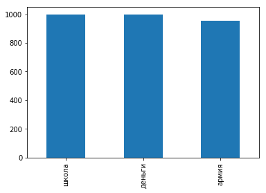

```python
df.target.value_counts().plot('bar')
```

```python
X = df.text
Y = df.target

Y = Y.replace("школа","1")
Y = Y.replace("деньги","2")
Y = Y.replace("армия","3")
```

## Первичная обработка и анализ данных.

- **Лемматизация текста – приведение слов к нормальной форме.**
- **Векторизация текста – преобразование текста в вектор.**
- **Классификация по 3 классам.**

#### Лемматизация:

**Исходный текст:**

[figure not shown]

**Лемматизированный текст:**

[figure not shown]

**Токен:**

[figure not shown]

#### Виды векторизации, используемые в данной работе

- **Bag of Words(CountVectorizer)**
- **HashingVectorizer**
- **TfIdfVectorizer**
- **Word2Vec**

#### Метрики точности :

- **Accuracy - процент правильно определенных элементов.**
- **Precision - процент правильно определенных элементов в классе.**
- **Recall - процент правильно предсказанных элементов класса в предсказанных элементов данного класса**

[figure not shown]

**В данной задаче использовалась метрика accuracy.**

**Кривая ошибок или ROC-кривая – графичекая характеристика качества бинарного классификатора, зависимость доли верных положительных классификаций от доли ложных положительных классификаций при варьировании порога решающего правила.**

**Так как наша выборка не бинарная, то используем метод OneVsRestClassifier, в котором выборка делается бинарной относительно каждого класса и на всех выборках рассматривается работа классификатора.**

### Вспомогательные функции

```python
def f_tokenizer(s):# функция лемматизации: превращение текста в список слов в нормальной форме,
    b = pd.read_excel('stop_words.xlsx')# с отсечением слов, которые не несут смысловой нагрузки, например, убирание предлогов
    stop_words = [b['stop_words'][q] for q in range(0,b.shape[0])]
    morph = pymorphy2.MorphAnalyzer()
    f = []
    punct = ['.',',',' ','"','!','(',')','?','+', '*', '-',':', ';', '?', '[', ']', '_','#','/']
    for r in punct:
        s = s.replace(r,' ')
    words = s.split(' ')
    for word in words:
        m = morph.parse(word)
        word = m[0]
        if word.tag.POS   in ('NOUN','ADJF'):# в данной задаче я оставил только существительные и прилагательные,
             if word.normal_form not in stop_words:# потому что данные части речи несут тематический смысл теста
                        f.append(word.normal_form+'_'+word.tag.POS)
    return(f)


#========================== Далее блок для визуализации корректности работы классификатора
def plot_confusion_matrix(cm, title='Confusion matrix', cmap=plt.cm.Blues):
    plt.imshow(cm, interpolation='nearest', cmap=cmap, vmin=0, vmax=1)
    plt.title(title)
    plt.colorbar()
    plt.clim(0, 1);
    tick_marks = np.arange(len(lenght))
    target_names = lenght
    plt.xticks(tick_marks, target_names, rotation=90)
    plt.yticks(tick_marks, target_names)
    plt.tight_layout()
    plt.ylabel('True label')
    plt.xlabel('Predicted label')
    plt.show()



def evaluate_prediction(predictions, target, title="Confusion matrix"):
    print('accuracy %s' % accuracy_score(target, predictions))
    cm = confusion_matrix(target, predictions)
    print('confusion matrix\n %s' % cm)
    print('(row=expected, col=predicted)')

    cm_normalized = cm.astype('float') / cm.sum(axis=1)[:, np.newaxis]
    plot_confusion_matrix(cm_normalized, title + ' Normalized')





def predict(classifier,Y,X):
    predictions = classifier.predict(Y)
    target = X
    evaluate_prediction(predictions, target)
```

```python
spisok = {
    ExtraTreesClassifier(n_estimators = 150,
                                                  max_features= 'sqrt',max_depth = 15 ,n_jobs=-1),

#DecisionTreeClassifier(random_state=0),
#MultinomialNB(),

RandomForestClassifier(n_estimators = 550,max_features= 'auto',max_depth = 10,n_jobs=-1),
linear_model.LogisticRegression(n_jobs=-1, C=1e5),
    xgboost.XGBClassifier(n_estimators= 100,max_depth = 15),
#KNeighborsClassifier(n_neighbors=25,n_jobs=-1)
         }
```

### Bag of Words

- **Находятся все уникальные слова из текстов.**
- **Вектор текста – количество каждого уникального слова в тексте.**

[figure not shown]

```python
%%time
# training
count_vectorizer = CountVectorizer(
    analyzer="word", tokenizer=f_tokenizer,
    preprocessor=None, max_features=30000)
train_data_features = count_vectorizer.fit_transform(X)
```

```
Wall time: 4min 3s
```

```python
Xtrain_bag,Xtest_bag,Ytrain_bag,Ytest_bag = train_test_split (train_data_features,
                                                                              Y,
                                                                              test_size=0.3,
                                                                              random_state=0)
```

```
accuracy 0.9007891770011274
confusion matrix
 [[273   5  18]
 [ 15 283  19]
 [ 15  16 243]]
(row=expected, col=predicted)
```

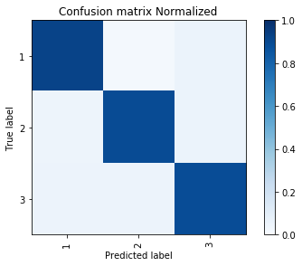

```
accuracy 0.923337091319053
confusion matrix
 [[270   7  19]
 [  5 289  23]
 [  3  11 260]]
(row=expected, col=predicted)
```

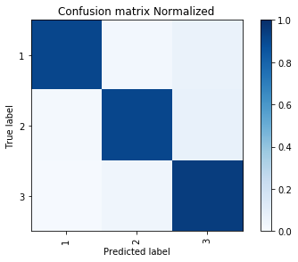

```
accuracy 0.8421645997745209
confusion matrix
 [[277  16   3]
 [ 14 294   9]
 [ 27  71 176]]
(row=expected, col=predicted)
```

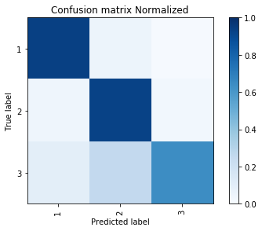

```
accuracy 0.8928974069898534
confusion matrix
 [[271  25   0]
 [  6 306   5]
 [  4  55 215]]
(row=expected, col=predicted)
```

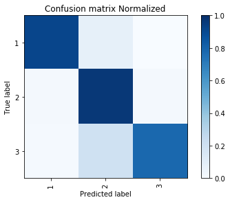

```python
lenght = [1,2,3]
for model in spisok:
    model.fit(Xtrain_bag,Ytrain_bag)
    predict(model, Xtest_bag,Ytest_bag)
```

```python
param_grid = {
    'n_estimators': [550,70,100,150,200,250],
    'max_features': ['auto', 'sqrt', 'log2'],
    'max_depth':[2,3,5,10,15]
}

for model in spisok:
    Grid_search_model = GridSearchCV(estimator=model, param_grid=param_grid, cv= 3,n_jobs = -1)
    Grid_search_model.fit(train_data_features, Y)
    print (Grid_search_model.best_params_)
    print(Grid_search_model.best_score_)
```

```
{'max_depth': 15, 'max_features': 'sqrt', 'n_estimators': 150}
0.8023688663282572
{'max_depth': 15, 'max_features': 'sqrt', 'n_estimators': 150}
0.8866328257191202
{'max_depth': 10, 'max_features': 'auto', 'n_estimators': 550}
0.9086294416243654
```

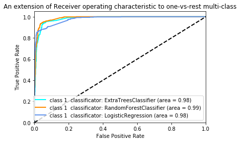

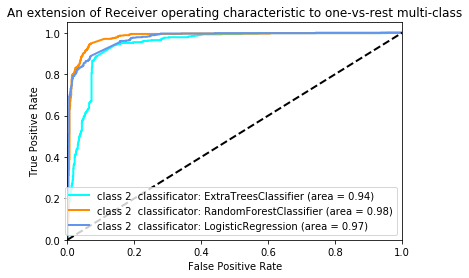

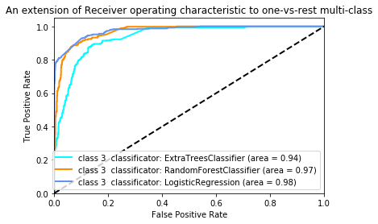

```python
y_score = []
y = label_binarize(Y, classes=['1','2','3'])
n_classes = y.shape[1]


X_train, X_test, y_train, y_test = train_test_split(train_data_features, y, test_size=.5,
                                                    random_state=0)
for model in spisok:
    classifier = OneVsRestClassifier(model)
    y_score.append( classifier.fit(X_train, y_train).predict_proba(X_test))


mmm = n_classes
classificator = ['ExtraTreesClassifier','RandomForestClassifier','LogisticRegression','XGBoost']
fpr = dict()
tpr = dict()
roc_auc = dict()
for j in range(len(y_score)):
    for i in range(n_classes):
        fpr[i+mmm*j], tpr[i+mmm*j], _ = roc_curve(y_test[:, i], y_score[j][:, i])
        roc_auc[i+mmm*j] = auc(fpr[i+mmm*j], tpr[i+mmm*j])

plt.figure()
lw = 2
colors = cycle(['aqua', 'darkorange', 'cornflowerblue'])
for i in range(n_classes):

    for j,color in zip(range(len(y_score)), colors):
        plt.plot(fpr[i+mmm*j], tpr[i+mmm*j], color=color, lw=lw,
                    label='class {0}  classificator: {1} (area = {2:0.2f})'
                    ''.format(i+1,classificator[j], roc_auc[i+mmm*j]))

    plt.plot([0, 1], [0, 1], 'k--', lw=lw)
    plt.xlim([0.0, 1.0])
    plt.ylim([0.0, 1.05])
    plt.xlabel('False Positive Rate')
    plt.ylabel('True Positive Rate')
    plt.title('An extension of Receiver operating characteristic to one-vs-rest multi-class')
    plt.legend(loc="lower right")
    plt.show()
```

## HashingVectorizer

- **Хеширование функцией Murmurhash3**
- **Для любого нового элемента найдется место в векторе**
- **Быстро происходит векторизация**
- **Не несет за собой словарь слов**

```python
spisok = {
    ExtraTreesClassifier(n_estimators = 150,
                                                  max_features= 'sqrt',max_depth = 15 ,n_jobs=-1),

#DecisionTreeClassifier(random_state=0),
#MultinomialNB(),

RandomForestClassifier(n_estimators = 550,max_features= 'auto',max_depth = 10,n_jobs=-1),
linear_model.LogisticRegression(n_jobs=-1, C=1e5),
    xgboost.XGBClassifier(n_estimators= 100,max_depth = 15),
#KNeighborsClassifier(n_neighbors=25,n_jobs=-1)
         }
```

```python
coder_hashing = HashingVectorizer(tokenizer=f_tokenizer, n_features=2**15)
trn_hashing = coder_hashing.fit_transform(X)
TruncSVD = TruncatedSVD (n_components = 30 )
trn_hashing = TruncSVD.fit_transform(trn_hashing)
print(trn_hashing[:5])
```

[output not shown]

```python
Xtrain_hashing,Xtest_hashing,Ytrain_hashing,Ytest_hashing = train_test_split (trn_hashing,
                                                                              Y,
                                                                              test_size=0.3,
                                                                              random_state=0)
```

```
accuracy 0.9098083427282976
confusion matrix
 [[267  12  17]
 [  9 281  27]
 [  3  12 259]]
(row=expected, col=predicted)
```

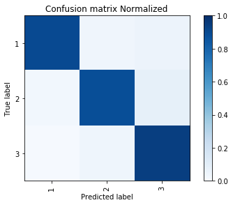

```
accuracy 0.8940248027057497
confusion matrix
 [[265  14  17]
 [ 12 277  28]
 [  8  15 251]]
(row=expected, col=predicted)
```

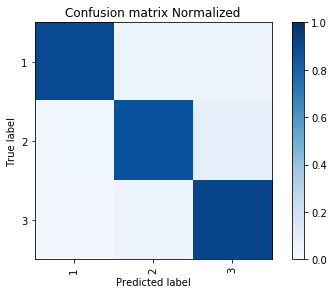

```
accuracy 0.9007891770011274
confusion matrix
 [[265  18  13]
 [ 16 283  18]
 [ 10  13 251]]
(row=expected, col=predicted)
```

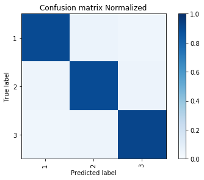

```
accuracy 0.8726042841037204
confusion matrix
 [[254  13  29]
 [ 10 263  44]
 [  6  11 257]]
(row=expected, col=predicted)
```

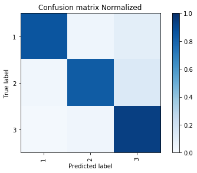

```python
lenght = [1,2,3]
for model in spisok:
    model.fit(Xtrain_hashing,Ytrain_hashing)
    predict(model, Xtest_hashing,Ytest_hashing)
```

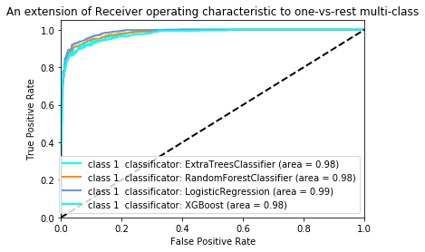

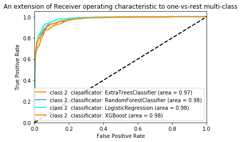

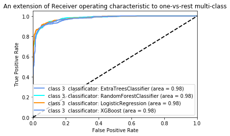

```python
y_score = []
y = label_binarize(Y, classes=['1','2','3'])
n_classes = y.shape[1]


X_train, X_test, y_train, y_test = train_test_split(trn_hashing, y, test_size=.5,
                                                    random_state=0)
for model in spisok:
    classifier = OneVsRestClassifier(model)
    y_score.append( classifier.fit(X_train, y_train).predict_proba(X_test))


mmm = n_classes
classificator = ['ExtraTreesClassifier','RandomForestClassifier','LogisticRegression','XGBoost']
fpr = dict()
tpr = dict()
roc_auc = dict()
for j in range(len(y_score)):
    for i in range(n_classes):
        fpr[i+mmm*j], tpr[i+mmm*j], _ = roc_curve(y_test[:, i], y_score[j][:, i])
        roc_auc[i+mmm*j] = auc(fpr[i+mmm*j], tpr[i+mmm*j])

plt.figure()
lw = 2
colors = cycle(['aqua', 'darkorange', 'cornflowerblue'])
for i in range(n_classes):

    for j,color in zip(range(len(y_score)), colors):
        plt.plot(fpr[i+mmm*j], tpr[i+mmm*j], color=color, lw=lw,
                    label='class {0}  classificator: {1} (area = {2:0.2f})'
                    ''.format(i+1,classificator[j], roc_auc[i+mmm*j]))

    plt.plot([0, 1], [0, 1], 'k--', lw=lw)
    plt.xlim([0.0, 1.0])
    plt.ylim([0.0, 1.05])
    plt.xlabel('False Positive Rate')
    plt.ylabel('True Positive Rate')
    plt.title('An extension of Receiver operating characteristic to one-vs-rest multi-class')
    plt.legend(loc="lower right")
    plt.show()
```

### TfidfVectorizer

- **(Term Frequensy)—это частотность слова, которая показывает, насколько часто слово встречается в документе.**
- **IDF(Inverse Document Frequensy) — это обратная частотность документов. Она показывает насколько важно слово для этого текста TF—IDF является перемножением этих двух чисел.**
- **У слов, которые встречаются почти в каждом тексте, уменьшается значимость(вес) и на классификацию влияют слова, которые редки.**

```python
spisok = {
    ExtraTreesClassifier(n_estimators = 150,
                                                  max_features= 'sqrt',max_depth = 15 ,n_jobs=-1),

#DecisionTreeClassifier(random_state=0),
#MultinomialNB(),

RandomForestClassifier(n_estimators = 550,max_features= 'auto',max_depth = 10,n_jobs=-1),
linear_model.LogisticRegression(n_jobs=-1, C=1e5),
    xgboost.XGBClassifier(n_estimators= 100,max_depth = 15),
#KNeighborsClassifier(n_neighbors=25,n_jobs=-1)
         }
```

```python
coder_Tfidf = TfidfVectorizer(tokenizer=f_tokenizer)
trn_Tfidf = coder_Tfidf.fit_transform(X)
print(trn_Tfidf[:4])
```

[output not shown]

```python
Xtrain_Tfidf,Xtest_Tfidf,Ytrain_Tfidf,Ytest_Tfidf = train_test_split (trn_Tfidf,
                                                                              Y,
                                                                              test_size=0.3,
                                                                              random_state=0)
```

```
accuracy 0.8726042841037204
confusion matrix
 [[280  13   3]
 [ 21 284  12]
 [ 15  49 210]]
(row=expected, col=predicted)
```

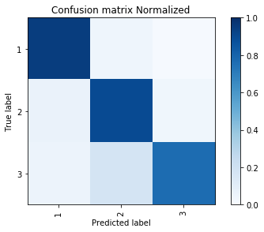

```
accuracy 0.8861330326944757
confusion matrix
 [[268  26   2]
 [  8 304   5]
 [  8  52 214]]
(row=expected, col=predicted)
```

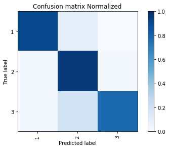

```
accuracy 0.9357384441939121
confusion matrix
 [[278   5  13]
 [ 12 288  17]
 [  3   7 264]]
(row=expected, col=predicted)
```

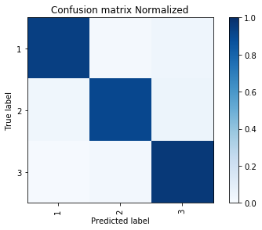

```
accuracy 0.9041713641488163
confusion matrix
 [[263  12  21]
 [  5 281  31]
 [  3  13 258]]
(row=expected, col=predicted)
```

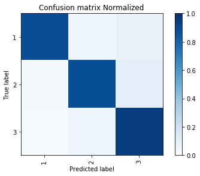

```python
lenght = [1,2,3]
for model in spisok:
    model.fit(Xtrain_Tfidf,Ytrain_Tfidf)
    predict(model, Xtest_Tfidf,Ytest_Tfidf)
```

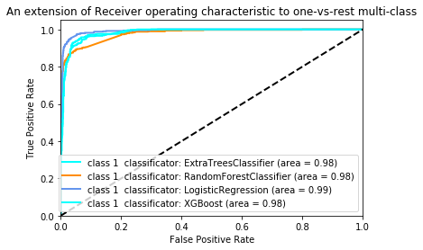

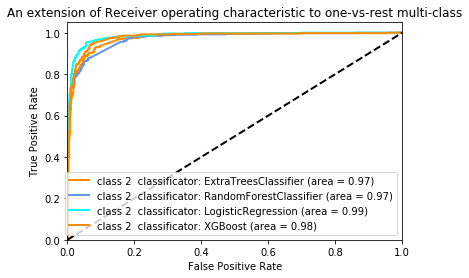

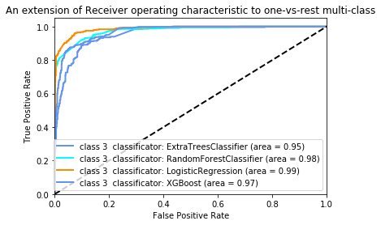

```python
y_score = []
y = label_binarize(Y, classes=['1','2','3'])
n_classes = y.shape[1]


X_train, X_test, y_train, y_test = train_test_split(trn_Tfidf, y, test_size=.5,
                                                    random_state=0)
for model in spisok:
    classifier = OneVsRestClassifier(model)
    y_score.append( classifier.fit(X_train, y_train).predict_proba(X_test))


mmm = n_classes
classificator = ['ExtraTreesClassifier','RandomForestClassifier','LogisticRegression','XGBoost']
fpr = dict()
tpr = dict()
roc_auc = dict()
for j in range(len(y_score)):
    for i in range(n_classes):
        fpr[i+mmm*j], tpr[i+mmm*j], _ = roc_curve(y_test[:, i], y_score[j][:, i])
        roc_auc[i+mmm*j] = auc(fpr[i+mmm*j], tpr[i+mmm*j])

plt.figure()
lw = 2
colors = cycle(['aqua', 'darkorange', 'cornflowerblue'])
for i in range(n_classes):

    for j,color in zip(range(len(y_score)), colors):
        plt.plot(fpr[i+mmm*j], tpr[i+mmm*j], color=color, lw=lw,
                    label='class {0}  classificator: {1} (area = {2:0.2f})'
                    ''.format(i+1,classificator[j], roc_auc[i+mmm*j]))

    plt.plot([0, 1], [0, 1], 'k--', lw=lw)
    plt.xlim([0.0, 1.0])
    plt.ylim([0.0, 1.05])
    plt.xlabel('False Positive Rate')
    plt.ylabel('True Positive Rate')
    plt.title('An extension of Receiver operating characteristic to one-vs-rest multi-class')
    plt.legend(loc="lower right")
    plt.show()
```

### Word2Vec

- **Вектора для слов создаются на основе вероятности встречи этого в данном контексте.**
- **Бывает двух типов: предобученный и обученный на собственных данных.**
- **Предобученные векторы сделал Mail.ru. В словаре: 267тыс. слов.**
- **Слова, которые близки по тематике, имеют близкие вектора.**

**Векторно близкие слова слову «сын_NOUN» :**

[figure not shown]

```python
def Word2Vec_transform(w2v, X):
        return np.array([
            np.mean([w2v[w] for w in f_tokenizer(words) if w in w2v.vocab]
                    or [np.zeros(w2v.vector_size)], axis=0)
            for words in X
        ])
```

```python
spisok = {
    ExtraTreesClassifier(n_estimators = 150,
                                                  max_features= 'sqrt',max_depth = 15 ,n_jobs=-1),

#DecisionTreeClassifier(random_state=0),
#MultinomialNB(),

RandomForestClassifier(n_estimators = 550,max_features= 'auto',max_depth = 10,n_jobs=-1),
linear_model.LogisticRegression(n_jobs=-1, C=1e5),
    xgboost.XGBClassifier(n_estimators= 100,max_depth = 15),
#KNeighborsClassifier(n_neighbors=25,n_jobs=-1)
         }
```

```python
from gensim.models.keyedvectors import KeyedVectors
word_vectors = KeyedVectors.load_word2vec_format('web_0_300_20.bin', binary=True)
```

```python
%%time
trn_Uvec =  Word2Vec_transform(word_vectors,X)
print(trn_Uvec)
```

```
[[ 5.64725101e-02  1.93400253e-02 -1.58644766e-02 ... -1.15954503e-02
  -2.67202780e-02  5.28552569e-02]
 [ 8.05382431e-02  4.28072140e-02  1.72703452e-02 ... -8.33438803e-03
  -4.47085798e-02  3.87246646e-02]
 [ 7.77187720e-02  4.84367050e-02 -1.53007405e-02 ...  5.91575615e-02
  -1.35072768e-02  2.25958228e-02]
 ...
 [-2.86720097e-02 -1.66953541e-02  1.70199517e-02 ...  5.59445471e-05
   1.37896156e-02 -4.27783169e-02]
 [-7.88607821e-02  4.19735443e-03  2.65960358e-02 ...  8.18207860e-03
  -4.99918777e-03 -3.36464345e-02]
 [-2.87519339e-02 -3.39436904e-02  3.28993499e-02 ...  1.16203269e-02
   3.87144163e-02 -6.50126487e-02]]
Wall time: 4min 44s
```

```python
Xtrain_Uvec,Xtest_Uvec,Ytrain_Uvec,Ytest_Uvec = train_test_split ( trn_Uvec,Y,test_size=0.3,random_state=241)
```

```
             precision    recall  f1-score   support

          1       0.92      0.92      0.92       301
          2       0.92      0.92      0.92       315
          3       0.90      0.90      0.90       271

avg / total       0.92      0.92      0.92       887

accuracy 0.9165727170236753
confusion matrix
 [[277  11  13]
 [ 11 291  13]
 [ 12  14 245]]
(row=expected, col=predicted)
```

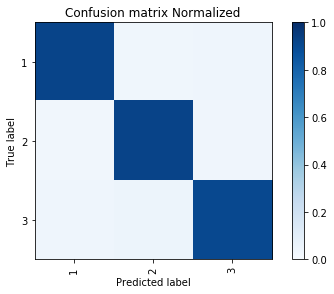

```
             precision    recall  f1-score   support

          1       0.92      0.93      0.92       301
          2       0.93      0.93      0.93       315
          3       0.91      0.91      0.91       271

avg / total       0.92      0.92      0.92       887

accuracy 0.9210822998872604
confusion matrix
 [[279  10  12]
 [ 12 292  11]
 [ 12  13 246]]
(row=expected, col=predicted)
```

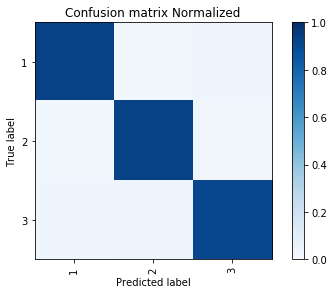

```
             precision    recall  f1-score   support

          1       0.91      0.91      0.91       301
          2       0.91      0.89      0.90       315
          3       0.89      0.92      0.91       271

avg / total       0.90      0.90      0.90       887

accuracy 0.9041713641488163
confusion matrix
 [[273  13  15]
 [ 20 279  16]
 [  8  13 250]]
(row=expected, col=predicted)
```

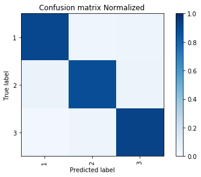

```
             precision    recall  f1-score   support

          1       0.92      0.92      0.92       301
          2       0.92      0.92      0.92       315
          3       0.92      0.91      0.91       271

avg / total       0.92      0.92      0.92       887

accuracy 0.9188275084554679
confusion matrix
 [[277  13  11]
 [ 13 291  11]
 [ 11  13 247]]
(row=expected, col=predicted)
```

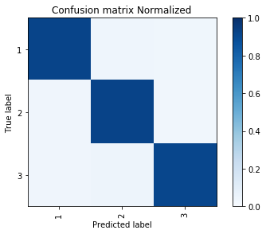

```python
lenght = [1,2,3]
for model in spisok:
    model.fit(Xtrain_Uvec,Ytrain_Uvec)
    a = model.predict(Xtest_Uvec)
    print(classification_report(Ytest_Uvec,a))
    predict(model,Xtest_Uvec,Ytest_Uvec)
```

```python
spisok = {
    ExtraTreesClassifier(n_estimators = 150,
                                                  max_features= 'sqrt',max_depth = 15 ,n_jobs=-1),

#DecisionTreeClassifier(random_state=0),
#MultinomialNB(),

RandomForestClassifier(n_estimators = 550,max_features= 'auto',max_depth = 10,n_jobs=-1),
linear_model.LogisticRegression(n_jobs=-1, C=1e5),
    xgboost.XGBClassifier(n_estimators= 100,max_depth = 15),
#KNeighborsClassifier(n_neighbors=25,n_jobs=-1)
         }
```

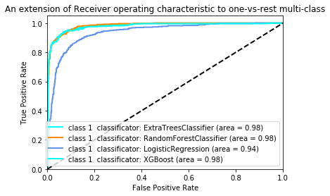

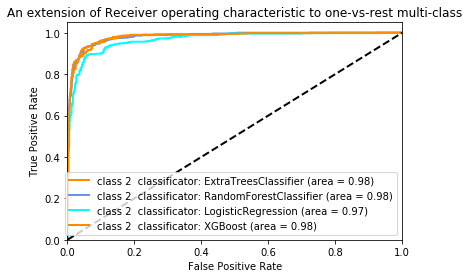

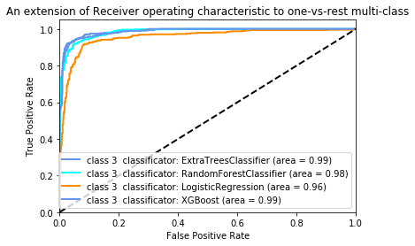

```python
y_score = []
y = label_binarize(Y, classes=['1','2','3'])
n_classes = y.shape[1]


X_train, X_test, y_train, y_test = train_test_split(trn_Uvec, y, test_size=.5,
                                                    random_state=0)
for model in spisok:
    classifier = OneVsRestClassifier(model)
    y_score.append( classifier.fit(X_train, y_train).predict_proba(X_test))


mmm = n_classes
classificator = ['ExtraTreesClassifier','RandomForestClassifier','LogisticRegression','XGBoost']
fpr = dict()
tpr = dict()
roc_auc = dict()
for j in range(len(y_score)):
    for i in range(n_classes):
        fpr[i+mmm*j], tpr[i+mmm*j], _ = roc_curve(y_test[:, i], y_score[j][:, i])
        roc_auc[i+mmm*j] = auc(fpr[i+mmm*j], tpr[i+mmm*j])

plt.figure()
lw = 2
colors = cycle(['aqua', 'darkorange', 'cornflowerblue'])
for i in range(n_classes):

    for j,color in zip(range(len(y_score)), colors):
        plt.plot(fpr[i+mmm*j], tpr[i+mmm*j], color=color, lw=lw,
                    label='class {0}  classificator: {1} (area = {2:0.2f})'
                    ''.format(i+1,classificator[j], roc_auc[i+mmm*j]))

    plt.plot([0, 1], [0, 1], 'k--', lw=lw)
    plt.xlim([0.0, 1.0])
    plt.ylim([0.0, 1.05])
    plt.xlabel('False Positive Rate')
    plt.ylabel('True Positive Rate')
    plt.title('An extension of Receiver operating characteristic to one-vs-rest multi-class')
    plt.legend(loc="lower right")
    plt.show()
```

### Классификация с помощью нейронной сети

```python
def remove_stop_words_and_tokenize(s):
    b = pd.read_excel('stop_words.xlsx')
    stop_words = [b['stop_words'][q] for q in range(0,b.shape[0])]
    morph = pymorphy2.MorphAnalyzer()
    f = ""
    punct = ['.',',',' ','"','!','(',')','?','+', '*', '-',':', ';', '?', '[', ']', '_','#','/']
    for r in punct:
        s = s.replace(r,' ')
    words = s.split(' ')
    for word in words:
        m = morph.parse(word)
        word = m[0]
        if word.tag.POS   in ('NOUN','ADJF'):
             if word.normal_form not in stop_words:
                        f = f + " " + word.normal_form+'_'+word.tag.POS
    return f
```

```python
X_clean = [remove_stop_words_and_tokenize(row) for row in X]
tokenizer = Tokenizer(num_words=10000)
tokenizer.fit_on_texts(X_clean)
X_NN = tokenizer.texts_to_matrix(X_clean)
Y_bin = label_binarize(Y, classes=['1','2','3'])
```

```python
TruncSVD = TruncatedSVD (n_components = 300)
trn_NN = TruncSVD.fit_transform(X_NN)
```

```python
Xtrain_NN,Xtest_NN,Ytrain_NN,Ytest_NN = train_test_split ( trn_NN,Y_bin,test_size=0.3,random_state=241)
```

#### Полносвязная нейронная сеть

```python
def NN_classificator(dense = 128,dropout = 0.3):
    model = Sequential()
    model.add(Dense(dense, input_dim=(Xtrain_NN.shape[1])))
    model.add(Activation('relu'))
    model.add(Dropout(dropout))
    model.add(Dense(dense- 30, input_dim=(Xtrain_NN.shape[1])))
    model.add(Activation('tanh'))
    model.add(Dropout(dropout))
    model.add(Dense(3))
    model.add(Activation('sigmoid'))
    model.compile(loss='binary_crossentropy',
                  optimizer='adam',
                  metrics=['accuracy'])
    return model
```

```python
for i in range(50,150,25):
    for j in np.arange(0.1,0.5,0.1):
        model = NN_classificator(i,j)
        history = model.fit(Xtrain_NN, Ytrain_NN,
                            batch_size=128,
                            epochs=100,
                            validation_data=(Xtest_NN, Ytest_NN),verbose = 0)
        a = model.evaluate(Xtest_NN,  Ytest_NN)
        print('Test set\n  Loss: {:0.3f}\n  Accuracy: {:0.3f}; Dense = {}, DropOut = {}'.format(a[0],a[1],i,j))
```

```
Test set
  Loss: 0.285
  Accuracy: 0.926; Dense = 50, DropOut = 0.1
Test set
  Loss: 0.279
  Accuracy: 0.935; Dense = 50, DropOut = 0.2
Test set
  Loss: 0.289
  Accuracy: 0.934; Dense = 50, DropOut = 0.30000000000000004
Test set
  Loss: 0.248
  Accuracy: 0.935; Dense = 50, DropOut = 0.4
Test set
  Loss: 0.373
  Accuracy: 0.927; Dense = 75, DropOut = 0.1
Test set
  Loss: 0.355
  Accuracy: 0.926; Dense = 75, DropOut = 0.2
Test set
  Loss: 0.321
  Accuracy: 0.933; Dense = 75, DropOut = 0.30000000000000004
Test set
  Loss: 0.319
  Accuracy: 0.935; Dense = 75, DropOut = 0.4
Test set
  Loss: 0.417
  Accuracy: 0.930; Dense = 100, DropOut = 0.1
Test set
  Loss: 0.398
  Accuracy: 0.930; Dense = 100, DropOut = 0.2
Test set
  Loss: 0.358
  Accuracy: 0.936; Dense = 100, DropOut = 0.30000000000000004
Test set
  Loss: 0.333
  Accuracy: 0.939; Dense = 100, DropOut = 0.4
Test set
  Loss: 0.422
  Accuracy: 0.927; Dense = 125, DropOut = 0.1
Test set
  Loss: 0.421
  Accuracy: 0.932; Dense = 125, DropOut = 0.2
Test set
  Loss: 0.365
  Accuracy: 0.932; Dense = 125, DropOut = 0.30000000000000004
Test set
  Loss: 0.395
  Accuracy: 0.935; Dense = 125, DropOut = 0.4
```

```python
best_model = NN_classificator(50,0.3)

history = best_model.fit(Xtrain_NN, Ytrain_NN,
                            batch_size=128,
                            epochs=100,
                            validation_data=(Xtest_NN, Ytest_NN),verbose = 1)
```

[output not shown]

```python
a = best_model.evaluate(Xtest_NN,  Ytest_NN)
print('Test set\n   Accuracy: {:0.3f}'.format(a[1]))
```

```
Test set
   Accuracy: 0.933
```

#### Word2Vec

```python
Xtrain_Uvec,Xtest_Uvec,Ytrain_Uvec,Ytest_Uvec = train_test_split ( trn_Uvec,Y_bin,test_size=0.3,random_state=241)
```

```python
best_model = NN_classificator(50,0.3)

history = best_model.fit(Xtrain_Uvec, Ytrain_Uvec,
                            batch_size=128,
                            epochs=100,
                            validation_data=(Xtest_Uvec, Ytest_Uvec),verbose = 1)
```

```
Train on 2068 samples, validate on 887 samples
```

```python
a = best_model.evaluate(Xtest_Uvec,  Ytest_Uvec)
print('Test set\n  Loss: {:0.3f}\n  Accuracy: {:0.3f}'.format(a[0],a[1]))
```

```
Test set
  Loss: 0.173
  Accuracy: 0.956
```

#### TF-IDF

```python
TruncSVD = TruncatedSVD (n_components = 300)
trn_TFIDF_NN = TruncSVD.fit_transform(trn_Tfidf)
Xtrain_Tfidf,Xtest_Tfidf,Ytrain_Tfidf,Ytest_Tfidf = train_test_split (trn_TFIDF_NN,
                                                                              Y_bin,
                                                                              test_size=0.3,
                                                                              random_state=0)
```

```python
best_model = NN_classificator(50,0.3)

history = best_model.fit(Xtrain_Tfidf, Ytrain_Tfidf,
                            batch_size=128,
                            epochs=20,
                            validation_data=(Xtest_Tfidf, Ytest_Tfidf),verbose = 1)
```

```
Train on 2068 samples, validate on 887 samples
```

```python
a = best_model.evaluate(Xtest_Tfidf,  Ytest_Tfidf)
print('Test set\n  Loss: {:0.3f}\n  Accuracy: {:0.3f}'.format(a[0],a[1]))
```

```
Test set
  Loss: 0.154
  Accuracy: 0.956
```

#### LSTM

```python
max_words = 100000
max_len = 400
X_clean = [remove_stop_words_and_tokenize(row) for row in X]
tokenizer = Tokenizer(num_words=max_words)
tokenizer.fit_on_texts(X_clean)
sequences = tokenizer.texts_to_sequences(X_clean)
sequences_matrix = sequence.pad_sequences(sequences,maxlen=max_len)
Y_bin = label_binarize(Y, classes=['1','2','3'])
```

```python
 Xtrain,Xtest,Ytrain,Ytest = train_test_split ( X_clean,Y_bin,test_size=0.3,random_state=241)
```

```python
sequences_train = tokenizer.texts_to_sequences(Xtrain)
sequences_matrix_train = sequence.pad_sequences(sequences_train,maxlen=max_len)

sequences_test = tokenizer.texts_to_sequences(Xtest)
sequences_matrix_test = sequence.pad_sequences(sequences_test,maxlen=max_len)
```

```python
model = Sequential()
model.add(Embedding(max_words,400,input_length=max_len))
model.add(LSTM(50, dropout=0.3))
model.add(Dense(30, activation='relu'))
model.add(Dense(3, activation='softmax'))
model.compile(loss='binary_crossentropy', optimizer='adam', metrics=['accuracy'])
```

```python
history = model.fit(sequences_matrix_train,Ytrain,
                            batch_size=250,
                            epochs=10,
                            validation_data=(sequences_matrix_test, Ytest),verbose = 1)
```

```
Train on 2068 samples, validate on 887 samples
```

```python
a = model.evaluate(sequences_matrix_test,  Ytest)
print('Test set\n  Accuracy: {:0.3f}'.format(a[1]))
```

```
Test set
  Accuracy: 0.945
```